# White wine story

by Alena

### Leonardo da Vinci once said the discovery of a good wine is increasingly better for mankind than the discovery of a new star.

What is the good wine? There are many factors that make the taste and quality of wine unique. Some of them that are going to be looked at are: acidity, pH level, sugar remained in wine and chlorides.

The data is variants of the Portuguese “Vinho Verde” wines, which is available https://s3.amazonaws.com/udacity-hosted-downloads/ud651/wineQualityWhites.csv, contains:

1 - fixed acidity: most acids involved with wine or fixed or nonvolatile (do not evaporate readily)

2 - volatile acidity: the amount of acetic acid in wine, which at too high of levels can lead to an unpleasant, vinegar taste

3 - citric acid: found in small quantities, citric acid can add ‘freshness’ and flavor to wines

4 - residual sugar: the amount of sugar remaining after fermentation stops, it’s rare to find wines with less than 1 gram/liter and wines with greater than 45 grams/liter are considered sweet

5 - chlorides: the amount of salt in the wine

6 - free sulfur dioxide: the free form of SO2 exists in equilibrium between molecular SO2 (as a dissolved gas) and bisulfite ion; it prevents microbial growth and the oxidation of wine

7 - total sulfur dioxide: amount of free and bound forms of S02; in low concentrations, SO2 is mostly undetectable in wine, but at free SO2 concentrations over 50 ppm, SO2 becomes evident in the nose and taste of wine

8 - density: the density of water is close to that of water depending on the percent alcohol and sugar content

9 - pH: describes how acidic or basic a wine is on a scale from 0 (very acidic) to 14 (very basic); most wines are between 3-4 on the pH scale

10 - sulphates: a wine additive which can contribute to sulfur dioxide gas (S02) levels, wich acts as an antimicrobial and antioxidant

11 - alcohol: the percent alcohol content of the wine

#### Making ourselves familiar with given data is the first step to look for quality and quantity of it.

First, what observations and features of data do we have? What data fields are there?

```
## [1] 4898   13
```

```
##  [1] "X"                    "fixed.acidity"        "volatile.acidity"
##  [4] "citric.acid"          "residual.sugar"       "chlorides"
##  [7] "free.sulfur.dioxide"  "total.sulfur.dioxide" "density"
## [10] "pH"                   "sulphates"            "alcohol"
## [13] "quality"
```

Then, values (attrubutes), strucrure and, finally, some general statistics

```
##   X fixed.acidity volatile.acidity citric.acid residual.sugar chlorides
## 1 1           7.0             0.27        0.36           20.7     0.045
## 2 2           6.3             0.30        0.34            1.6     0.049
## 3 3           8.1             0.28        0.40            6.9     0.050
## 4 4           7.2             0.23        0.32            8.5     0.058
## 5 5           7.2             0.23        0.32            8.5     0.058
## 6 6           8.1             0.28        0.40            6.9     0.050
##   free.sulfur.dioxide total.sulfur.dioxide density   pH sulphates alcohol
## 1                  45                  170  1.0010 3.00      0.45     8.8
## 2                  14                  132  0.9940 3.30      0.49     9.5
## 3                  30                   97  0.9951 3.26      0.44    10.1
## 4                  47                  186  0.9956 3.19      0.40     9.9
## 5                  47                  186  0.9956 3.19      0.40     9.9
## 6                  30                   97  0.9951 3.26      0.44    10.1
##   quality
## 1       6
## 2       6
## 3       6
## 4       6
## 5       6
## 6       6
```

```
## 'data.frame':    4898 obs. of  13 variables:
##  $ X                   : int  1 2 3 4 5 6 7 8 9 10 ...
##  $ fixed.acidity       : num  7 6.3 8.1 7.2 7.2 8.1 6.2 7 6.3 8.1 ...
##  $ volatile.acidity    : num  0.27 0.3 0.28 0.23 0.23 0.28 0.32 0.27 0.3 0.22 ...
##  $ citric.acid         : num  0.36 0.34 0.4 0.32 0.32 0.4 0.16 0.36 0.34 0.43 ...
##  $ residual.sugar      : num  20.7 1.6 6.9 8.5 8.5 6.9 7 20.7 1.6 1.5 ...
##  $ chlorides           : num  0.045 0.049 0.05 0.058 0.058 0.05 0.045 0.045 0.049 0.044 ...
##  $ free.sulfur.dioxide : num  45 14 30 47 47 30 30 45 14 28 ...
##  $ total.sulfur.dioxide: num  170 132 97 186 186 97 136 170 132 129 ...
##  $ density             : num  1.001 0.994 0.995 0.996 0.996 ...
##  $ pH                  : num  3 3.3 3.26 3.19 3.19 3.26 3.18 3 3.3 3.22 ...
##  $ sulphates           : num  0.45 0.49 0.44 0.4 0.4 0.44 0.47 0.45 0.49 0.45 ...
##  $ alcohol             : num  8.8 9.5 10.1 9.9 9.9 10.1 9.6 8.8 9.5 11 ...
##  $ quality             : int  6 6 6 6 6 6 6 6 6 6 ...
```

```
##        X        fixed.acidity    volatile.acidity  citric.acid
##  Min.   :   1   Min.   : 3.800   Min.   :0.0800   Min.   :0.0000
##  1st Qu.:1225   1st Qu.: 6.300   1st Qu.:0.2100   1st Qu.:0.2700
##  Median :2450   Median : 6.800   Median :0.2600   Median :0.3200
##  Mean   :2450   Mean   : 6.855   Mean   :0.2782   Mean   :0.3342
##  3rd Qu.:3674   3rd Qu.: 7.300   3rd Qu.:0.3200   3rd Qu.:0.3900
##  Max.   :4898   Max.   :14.200   Max.   :1.1000   Max.   :1.6600
##  residual.sugar     chlorides       free.sulfur.dioxide
##  Min.   : 0.600   Min.   :0.00900   Min.   :  2.00
##  1st Qu.: 1.700   1st Qu.:0.03600   1st Qu.: 23.00
##  Median : 5.200   Median :0.04300   Median : 34.00
##  Mean   : 6.391   Mean   :0.04577   Mean   : 35.31
##  3rd Qu.: 9.900   3rd Qu.:0.05000   3rd Qu.: 46.00
##  Max.   :65.800   Max.   :0.34600   Max.   :289.00
##  total.sulfur.dioxide    density             pH          sulphates
##  Min.   :  9.0        Min.   :0.9871   Min.   :2.720   Min.   :0.2200
##  1st Qu.:108.0        1st Qu.:0.9917   1st Qu.:3.090   1st Qu.:0.4100
##  Median :134.0        Median :0.9937   Median :3.180   Median :0.4700
##  Mean   :138.4        Mean   :0.9940   Mean   :3.188   Mean   :0.4898
##  3rd Qu.:167.0        3rd Qu.:0.9961   3rd Qu.:3.280   3rd Qu.:0.5500
##  Max.   :440.0        Max.   :1.0390   Max.   :3.820   Max.   :1.0800
##     alcohol         quality
##  Min.   : 8.00   Min.   :3.000
##  1st Qu.: 9.50   1st Qu.:5.000
##  Median :10.40   Median :6.000
##  Mean   :10.51   Mean   :5.878
##  3rd Qu.:11.40   3rd Qu.:6.000
##  Max.   :14.20   Max.   :9.000
```

The normal range for fixed acidity is 6.3 to 7.3 g / dm^3. As for sugar, 75% of wines in our dataset have below 9.9 mg / dm^3 sugar remaining after fermentation stops. Average alcohol percentage in our dataset is about 10.51

#### Analyzing data by looking at its destributions

Since we have great measure of wine given to us - “quality”, we can explore its dependance on other variables or what make while wine better quality.

For better understanding, let’s create ordered factor of quality, which help us see differentce between, for example, acidity and quality on plot.

Before we jump right in analyzing differences, we need to see destribution of acidity level, quality and pH in our data.

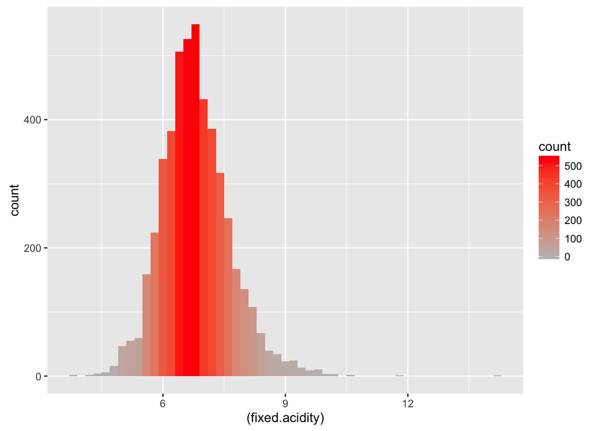

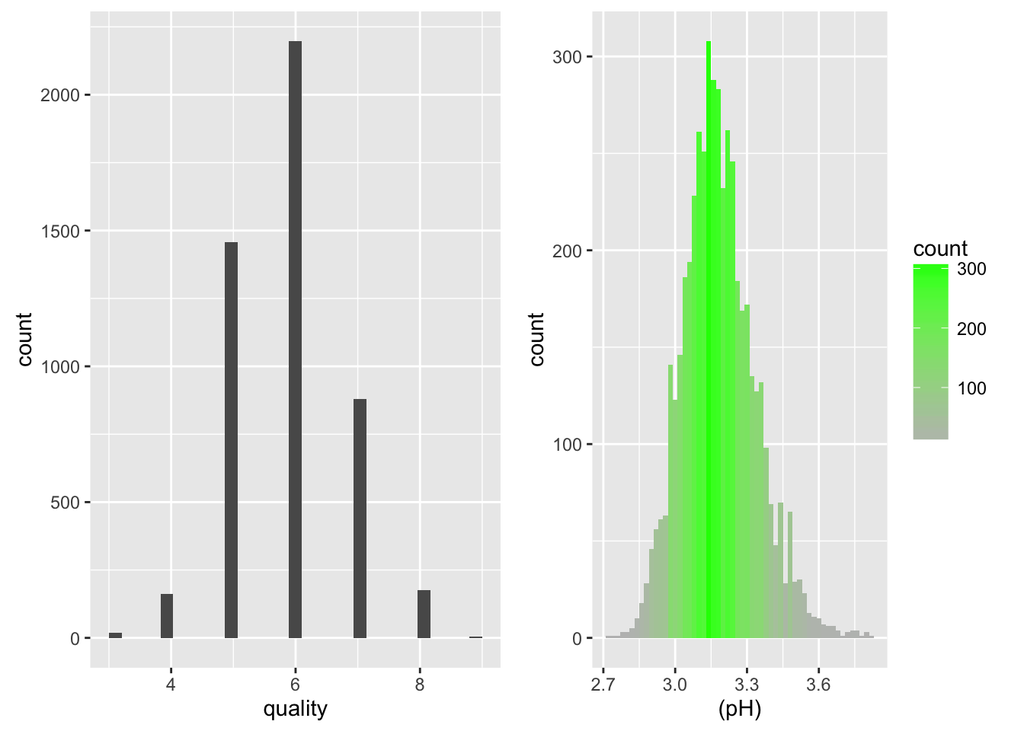

That is really good that we have normal distribution of acidity, pH in our data.

Now, time to compare it to quality with box ploting, which let us better evalate the difference of quolity factors:

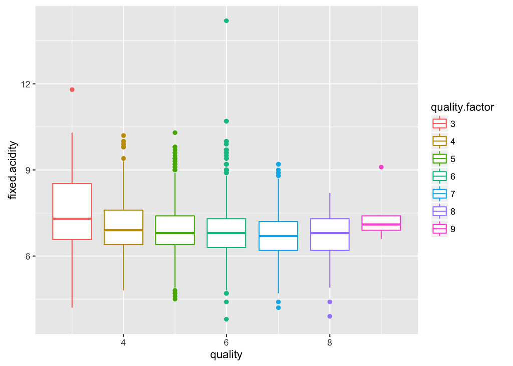

We see that we have some outliers, but it does not affrect over all picture much, so we leave them. The result is interesting, we don’t have any quality factor that stands up. All of them are pretty equal. Moreover, we have three type of acidity: fixed - usualy has a range between 6 and 8, where volatile has .1 and .5 and citric - from 0 to 1.

I want to check citric and volatile acidity levels in different quality factors:

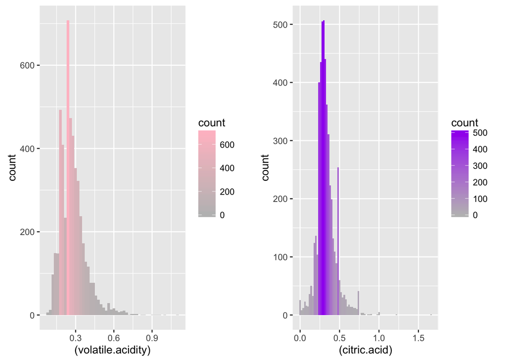

Here, we have the most of wines in our dataset are between 0.25 and 6 for volatile and .2 and .5 for citric acidity. This gives us unexpected result where volatile acidity level is a little bit above normal range.

Look at comparison of quality and pH level with boxploting as well:

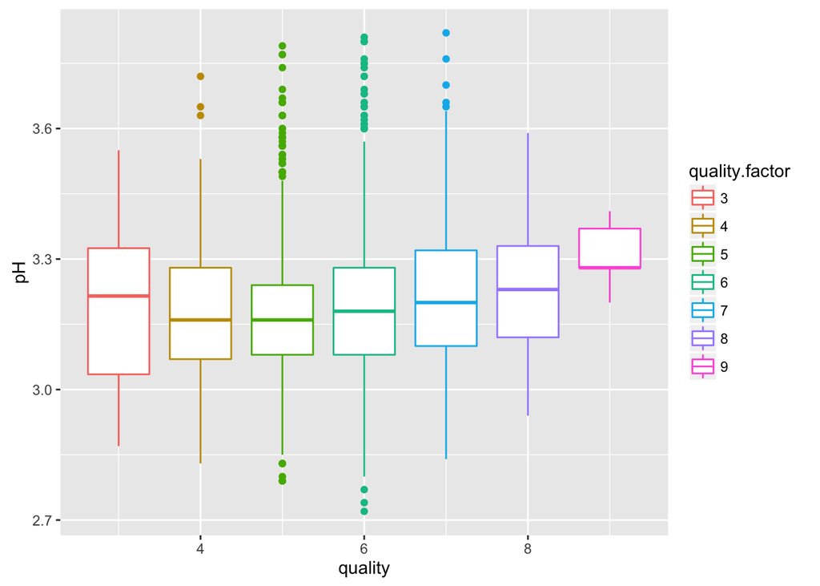

We have a lot of factors (variables) to look at quality of white wine, but as we have stated in the beginning, we will take a look only at a couple of them right now. Acidity and pH level were explored, now it is time to take a look at sugar and chlorides. Let’s look at Sugar’s destributions and impact of it on quality:

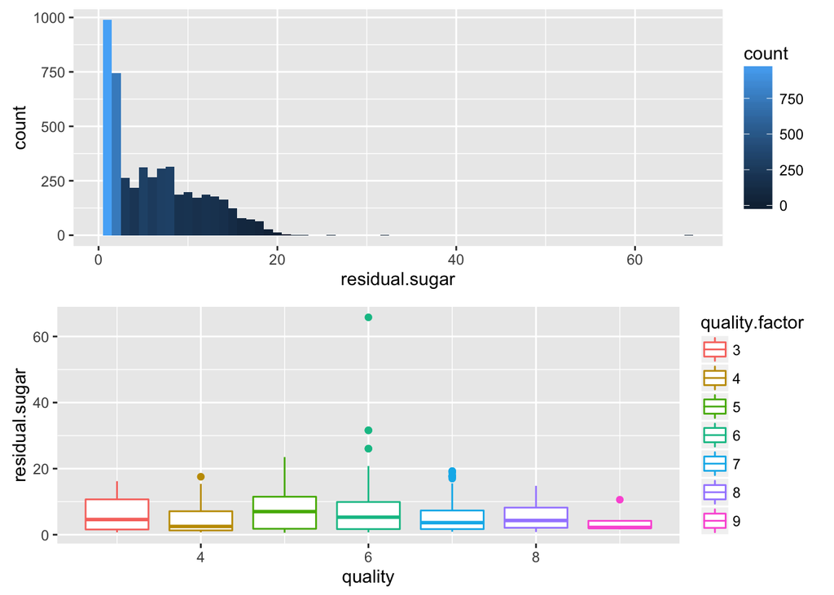

Sugar in our dataset has a pick close to zero and maximum values as 60 (see have seen in summary), but we do not anticipate that it will have a destribution leaning on the left side. Where boxplots do not explain the left sided destribution of sugar; however,it gives us the idea that premium quality contains almost no sugar.

What about chlorides? And it relationship to pH and quality

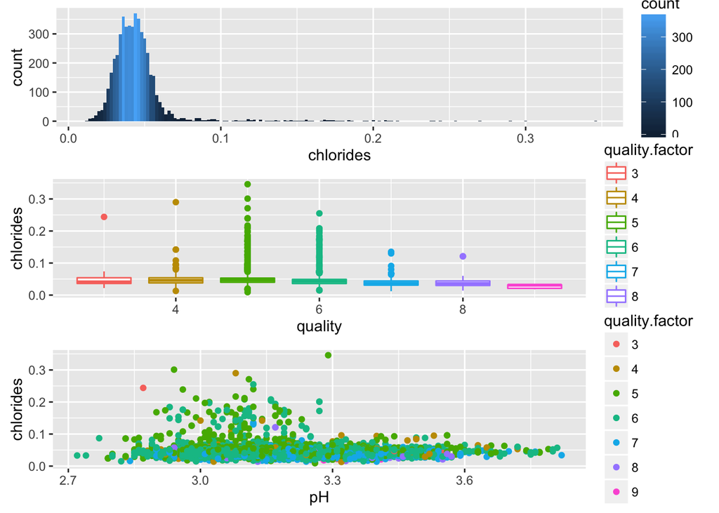

The dataset has some outliers, but over all shape of destribution looks normal. Where as box plot has pritty much the same avarage values for qualities. However, we see interesting pattern here, white wines with better quality tend to have less chlorides.

#### Looking for correlation between variables

First, wee need to exclude variables that do not have any correlation. Start from pH level and look at its correlection with other variables, which we analyzing (acidity, quality, sugar and chlorides). Our results were that pH level has almost no correlations, but the plot shows strong negative red colored correlation with Fixed.acidity. After looking at acidity in our data, we find a correlation with density. Moreover, we dont anticipate to look into dencity untill perform correlation analytics:

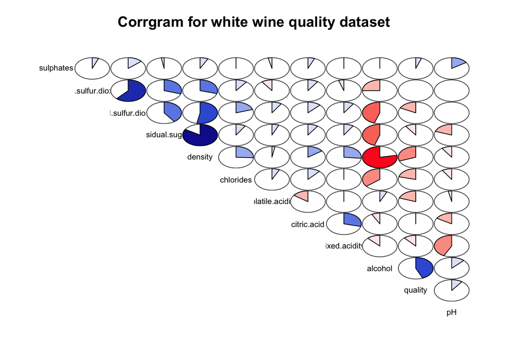

And since we are looking into what factors effect quality of white wine, we have to explore this relationship closer. Ploting will help us see it, but, in the same time, I want to explore how alcohol and pH level impact quality:

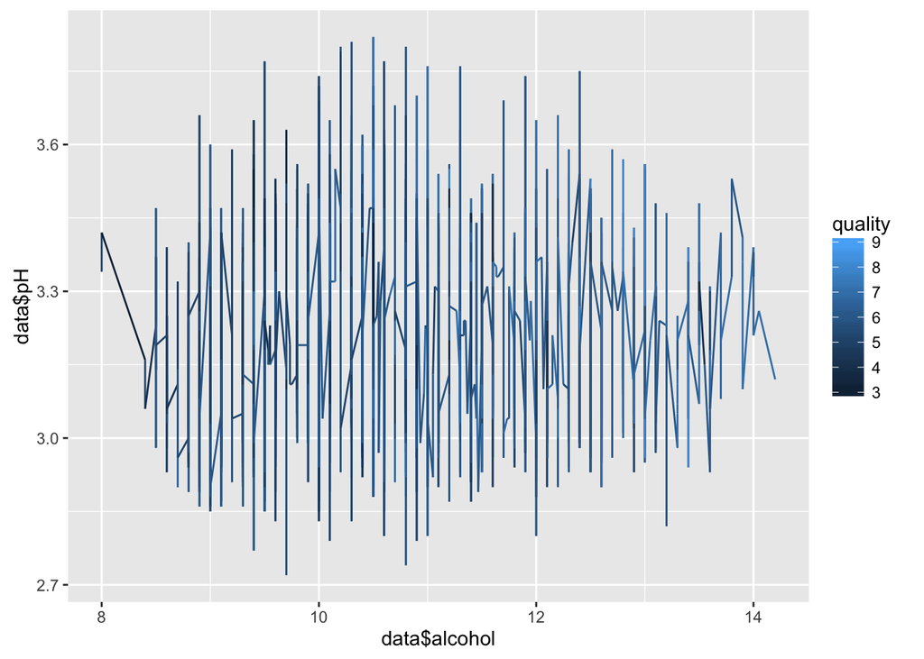

I cannot understand its relationships on this plot, let’s try to see what level of alcohol is in the range of high qualities (7-9):

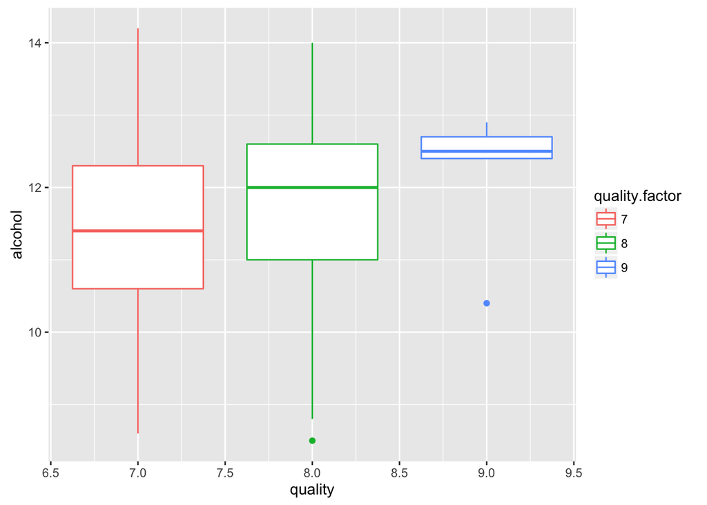

Here we see that higher quality white wine contains more than 11 percent of alcohol. Let’s specify pH level around 3.3 and alcohol more than 11.

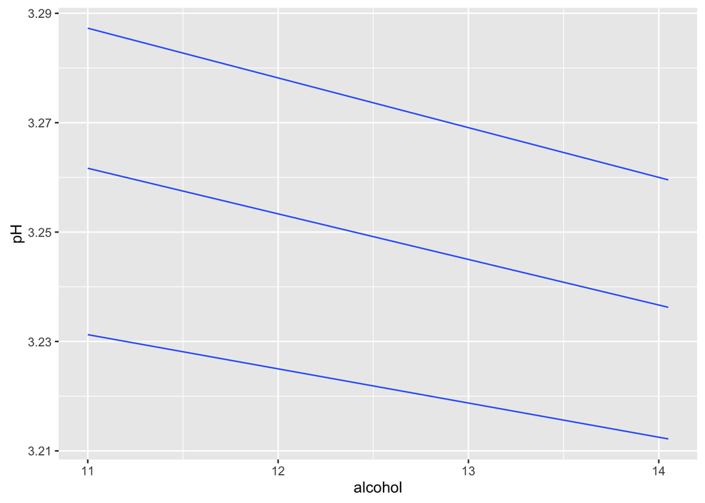

We see that quantile plot shows that level of pH going down when alcohol level is going up for better quality. Let’s look at it separetely:

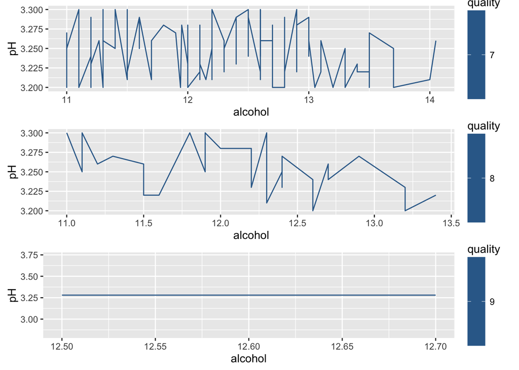

Here, we have 7’s quality shows a small change, where the highest 9th level has stable pH level. That is really interesing findings.

#### Predicting Wine Quality

By using informayion that we gather from analyzing patterns in wine quality to predict it:

```
##
##    3    4    5    6    7    8    9
##   20  163 1457 2198  880  175    5
```

We has accuracy - highest value of rows in dataset devided by sum of all rows values: 2198/(20+163+1457+2198+880+175+5) = 0.4487

Looking into our analytics, we saw that twe have a strong relationship between wine quality and its alcohol percentage, so it makes sence to predict the quality of wine just based on its alcohol percentage

```
##    pred
##        3    4    5    6    7    8    9
##   3    0    0    5   15    0    0    0
##   4    0    0   57  103    3    0    0
##   5    0    0  738  710    9    0    0
##   6    0    0  523 1578   97    0    0
##   7    0    0  100  636  144    0    0
##   8    0    0   18  120   37    0    0
##   9    0    0    0    3    2    0    0
```

Here we that most our predictions alines arpund middle values of quality 5 - 7. It gives me idea that our dataset does not have enough information on high quality of white wine.

Since we were trying to find our factors that effect high quality of white wine, we obviously can get more data on that and do more analytics based on that new factors.

#### Final plots and Summary

We explore wine quality first to determent were our data alines.

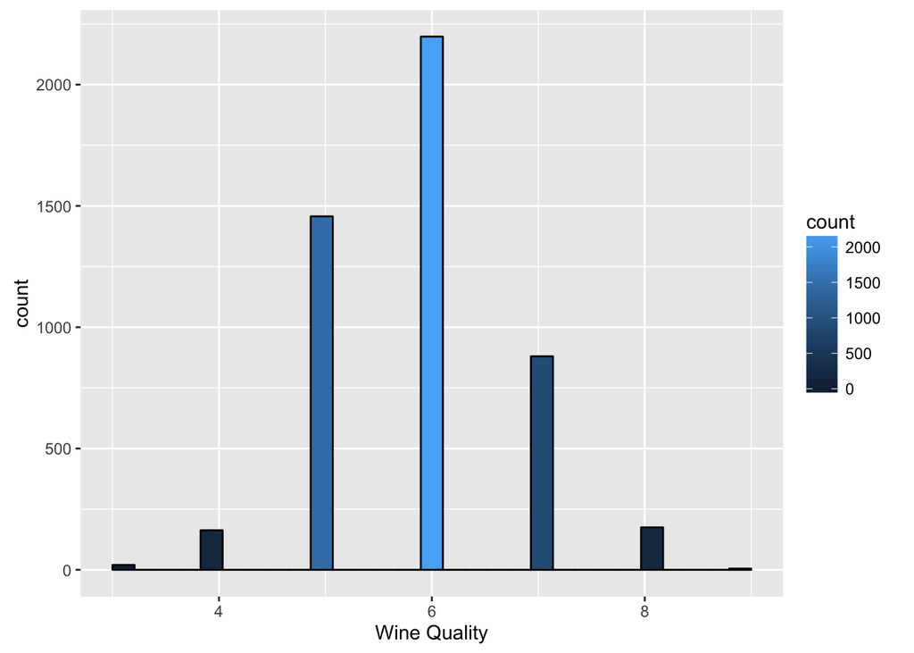

As the result, we see that most of your white wines have quality between 5 and 7. However, we wanted to learn about highest quality factors. In analytics section, we determened that for high quality: pH level a range between 3.2 and 3.3, almost no sugar involved and alcohol level more or equals 11 persent. What about density that we learn at correlation level. Here we can plot density and alcohol dependency of quality factor:

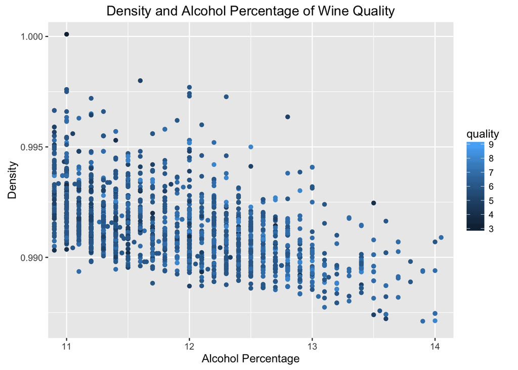

We found out that the higher the alcohol percentage means the lower is the density for all qualities. Is it true for high qualities?

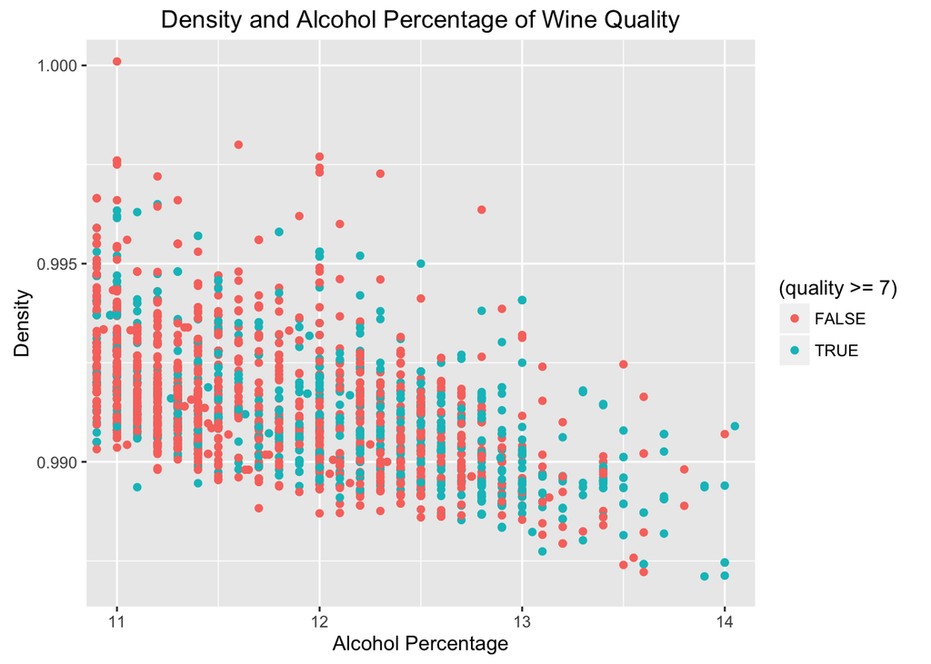

#### Reflection

After making statement, I am convinced that Alcohol percentage is one of the most important factors to decide on the quality of white wine. Moveover, remaining sugar contributes to it in wine on if more sugar left after fermentation, the less the percentage of alcohol can be found in a wine. There were more factors effecting the quality and we gave a pritty good picture for them in the body. However, for future analytics, I would suggest take more data with higher qualities and look for patterns with other factors like acidity and sulphates more closer because we definatelly will have interesing results there.

Regarding overall analytics, because of small size of dataset we were able to do it fairly quick, but if your data is big, we have to split it or samplify to run analytics and only then look for particular patterns not test for everything.

#### References

You can finf them in my text.